# Part I - Ford GoBike System Data

## Introduction

This data set includes information about individual rides made in a bike-sharing system covering the greater San Francisco Bay area.

## Preliminary Wrangling

```python
# import all packages and set plots to be embedded inline
import numpy as np
import pandas as pd
import folium
import matplotlib.pyplot as plt
import seaborn as sb

%matplotlib inline
```

Loading dataset from the csv file.

```python
#loading the dataset
bike = pd.read_csv('201902-fordgobike-tripdata.csv')
```

### What is the structure of your dataset?

```python
bike.shape
```

```
(183412, 16)
```

The original dataset contains 183412 rows and 16 columns.

```python
bike.info()
```

```
<class 'pandas.core.frame.DataFrame'>
RangeIndex: 183412 entries, 0 to 183411
Data columns (total 16 columns):
 #   Column                   Non-Null Count   Dtype
---  ------                   --------------   -----
 0   duration_sec             183412 non-null  int64
 1   start_time               183412 non-null  object
 2   end_time                 183412 non-null  object
 3   start_station_id         183215 non-null  float64
 4   start_station_name       183215 non-null  object
 5   start_station_latitude   183412 non-null  float64
 6   start_station_longitude  183412 non-null  float64
 7   end_station_id           183215 non-null  float64
 8   end_station_name         183215 non-null  object
 9   end_station_latitude     183412 non-null  float64
 10  end_station_longitude    183412 non-null  float64
 11  bike_id                  183412 non-null  int64
 12  user_type                183412 non-null  object
 13  member_birth_year        175147 non-null  float64
 14  member_gender            175147 non-null  object
 15  bike_share_for_all_trip  183412 non-null  object
dtypes: float64(7), int64(2), object(7)
memory usage: 22.4+ MB
```

Dropping NaNs.

```python
bike.dropna(inplace=True)
```

### Fixing the datatypes

```python
bike.duration_sec=bike.duration_sec.astype(float)
bike.start_station_id = bike.start_station_id.astype(int)
bike.end_station_id = bike.end_station_id.astype(int)
bike.member_birth_year = bike.member_birth_year.astype(int)
bike.start_station_name = bike.start_station_name.astype(str)
bike.end_station_name = bike.end_station_name.astype(str)
bike.start_time = bike.start_time.astype('datetime64[ns]')
bike.end_time = bike.end_time.astype('datetime64[ns]')
# convert user_type, member_gender, bike_share_for_all_trip into ordered categorical types
ordinal_var_dict = {'user_type': ['Customer','Subscriber'],
                    'member_gender': ['Male','Female','Other'],
                    'bike_share_for_all_trip': ['Yes','No']}

for var in ordinal_var_dict:
    ordered_var = pd.api.types.CategoricalDtype(ordered = True,
                                                categories = ordinal_var_dict[var])
    bike[var] = bike[var].astype(ordered_var)
```

Adding extra columns for the sake of better understanding.

```python
bike['member_age'] = 2021 - bike['member_birth_year']
bike['duration_hours'] = bike['duration_sec']/3600
```

```python
bike.info()
```

```
<class 'pandas.core.frame.DataFrame'>
Int64Index: 174952 entries, 0 to 183411
Data columns (total 18 columns):
 #   Column                   Non-Null Count   Dtype
---  ------                   --------------   -----
 0   duration_sec             174952 non-null  float64
 1   start_time               174952 non-null  datetime64[ns]
 2   end_time                 174952 non-null  datetime64[ns]
 3   start_station_id         174952 non-null  int64
 4   start_station_name       174952 non-null  object
 5   start_station_latitude   174952 non-null  float64
 6   start_station_longitude  174952 non-null  float64
 7   end_station_id           174952 non-null  int64
 8   end_station_name         174952 non-null  object
 9   end_station_latitude     174952 non-null  float64
 10  end_station_longitude    174952 non-null  float64
 11  bike_id                  174952 non-null  int64
 12  user_type                174952 non-null  category
 13  member_birth_year        174952 non-null  int64
 14  member_gender            174952 non-null  category
 15  bike_share_for_all_trip  174952 non-null  category
 16  member_age               174952 non-null  int64
 17  duration_hours           174952 non-null  float64
dtypes: category(3), datetime64[ns](2), float64(6), int64(5), object(2)
memory usage: 21.9+ MB
```

After dropping NaNs only 174952 rows are left.

```python
bike.describe()
```

|  | duration_sec | start_station_id | start_station_latitude | start_station_longitude | end_station_id | end_station_latitude | end_station_longitude | bike_id | member_birth_year | member_age | duration_hours |
| --- | --- | --- | --- | --- | --- | --- | --- | --- | --- | --- | --- |
| count | 174952.000000 | 174952.000000 | 174952.000000 | 174952.000000 | 174952.000000 | 174952.000000 | 174952.000000 | 174952.000000 | 174952.000000 | 174952.000000 | 174952.000000 |
| mean | 704.002744 | 139.002126 | 37.771220 | -122.351760 | 136.604486 | 37.771414 | -122.351335 | 4482.587555 | 1984.803135 | 36.196865 | 0.195556 |
| std | 1642.204905 | 111.648819 | 0.100391 | 0.117732 | 111.335635 | 0.100295 | 0.117294 | 1659.195937 | 10.118731 | 10.118731 | 0.456168 |
| min | 61.000000 | 3.000000 | 37.317298 | -122.453704 | 3.000000 | 37.317298 | -122.453704 | 11.000000 | 1878.000000 | 20.000000 | 0.016944 |
| 25% | 323.000000 | 47.000000 | 37.770407 | -122.411901 | 44.000000 | 37.770407 | -122.411647 | 3799.000000 | 1980.000000 | 29.000000 | 0.089722 |
| 50% | 510.000000 | 104.000000 | 37.780760 | -122.398279 | 101.000000 | 37.781010 | -122.397437 | 4960.000000 | 1987.000000 | 34.000000 | 0.141667 |
| 75% | 789.000000 | 239.000000 | 37.797320 | -122.283093 | 238.000000 | 37.797673 | -122.286533 | 5505.000000 | 1992.000000 | 41.000000 | 0.219167 |
| max | 84548.000000 | 398.000000 | 37.880222 | -121.874119 | 398.000000 | 37.880222 | -121.874119 | 6645.000000 | 2001.000000 | 143.000000 | 23.485556 |

```python
bike.head(5)
```

|  | duration_sec | start_time | end_time | start_station_id | start_station_name | start_station_latitude | start_station_longitude | end_station_id | end_station_name | end_station_latitude | end_station_longitude | bike_id | user_type | member_birth_year | member_gender | bike_share_for_all_trip | member_age | duration_hours |
| --- | --- | --- | --- | --- | --- | --- | --- | --- | --- | --- | --- | --- | --- | --- | --- | --- | --- | --- |
| 0 | 52185.0 | 2019-02-28 17:32:10.145 | 2019-03-01 08:01:55.975 | 21 | Montgomery St BART Station (Market St at 2nd St) | 37.789625 | -122.400811 | 13 | Commercial St at Montgomery St | 37.794231 | -122.402923 | 4902 | Customer | 1984 | Male | No | 37 | 14.495833 |
| 2 | 61854.0 | 2019-02-28 12:13:13.218 | 2019-03-01 05:24:08.146 | 86 | Market St at Dolores St | 37.769305 | -122.426826 | 3 | Powell St BART Station (Market St at 4th St) | 37.786375 | -122.404904 | 5905 | Customer | 1972 | Male | No | 49 | 17.181667 |
| 3 | 36490.0 | 2019-02-28 17:54:26.010 | 2019-03-01 04:02:36.842 | 375 | Grove St at Masonic Ave | 37.774836 | -122.446546 | 70 | Central Ave at Fell St | 37.773311 | -122.444293 | 6638 | Subscriber | 1989 | Other | No | 32 | 10.136111 |
| 4 | 1585.0 | 2019-02-28 23:54:18.549 | 2019-03-01 00:20:44.074 | 7 | Frank H Ogawa Plaza | 37.804562 | -122.271738 | 222 | 10th Ave at E 15th St | 37.792714 | -122.248780 | 4898 | Subscriber | 1974 | Male | Yes | 47 | 0.440278 |
| 5 | 1793.0 | 2019-02-28 23:49:58.632 | 2019-03-01 00:19:51.760 | 93 | 4th St at Mission Bay Blvd S | 37.770407 | -122.391198 | 323 | Broadway at Kearny | 37.798014 | -122.405950 | 5200 | Subscriber | 1959 | Male | No | 62 | 0.498056 |

### What is/are the main feature(s) of interest in your dataset?

- visualizing the location of stations on the map;
- trip duration;
- membership type, gender and age of a customer;
- time when the ride was performed.

### What features in the dataset do you think will help support your investigation into your feature(s) of interest?

- `start_station_latitude`, `start_station_longitude` and.`end_station_latitude`, `end_station_longitude` will support visualisation of station locations;
- `member_birth_year` is used to generate `member_age`;
- `duration_sec` is used to generate `duration_hours`;
- `start_time` to extract `month`, `day` and `hour` to analyze the bahaviour of users based on these features;
- `start_station_name` and `end_station_name` to find out what are the most poular sations.

## Creating the Map of Station Locations

Extracting bike start locations into a separate dataframe.

```python
bike_start_locations = bike[["start_station_id", "start_station_latitude", "start_station_longitude"]]
bike_start_locations.rename(columns={'start_station_id': 'ID','start_station_latitude': 'Latitude', 'start_station_longitude': 'Longitude'}, inplace=True)
```

```python
bike_start_locations.head()
```

|  | ID | Latitude | Longitude |
| --- | --- | --- | --- |
| 0 | 21 | 37.789625 | -122.400811 |
| 2 | 86 | 37.769305 | -122.426826 |
| 3 | 375 | 37.774836 | -122.446546 |
| 4 | 7 | 37.804562 | -122.271738 |
| 5 | 93 | 37.770407 | -122.391198 |

```python
bike_start_locations.shape
```

```
(174952, 3)
```

Extracting bike start locations into a separate dataframe.

```python
bike_end_locations = bike[["end_station_id", "end_station_latitude", "end_station_longitude"]]
bike_end_locations.rename(columns={'end_station_id': 'ID','end_station_latitude': 'Latitude', 'end_station_longitude': 'Longitude'}, inplace=True)
```

```python
bike_end_locations.head()
```

|  | ID | Latitude | Longitude |
| --- | --- | --- | --- |
| 0 | 13 | 37.794231 | -122.402923 |
| 2 | 3 | 37.786375 | -122.404904 |
| 3 | 70 | 37.773311 | -122.444293 |
| 4 | 222 | 37.792714 | -122.248780 |
| 5 | 323 | 37.798014 | -122.405950 |

```python
bike_end_locations.shape
```

```
(174952, 3)
```

Concating start and end locations, dropping the duplicates.

```python
bike_locations = pd.concat([bike_start_locations,bike_end_locations])
bike_locations.drop_duplicates(inplace=True)
bike_locations.shape
```

```
(329, 3)
```

Mapping bike locations.

```python
m1= folium.Map(location=[bike_locations.Latitude.mean(), bike_locations.Longitude.mean()], zoom_start=12, control_scale=True)
```

```python
for each in bike_locations[:329].iterrows():
    folium.CircleMarker(
    location=[each[1]["Latitude"], each[1]["Longitude"]],
    radius=3,
    popup=str(each[1]["ID"]),
        #str(each[1]["Latitude"]) + "," + str(each[1]["Longitude"]),
    color="#3186cc",
    fill=True,
    fill_color="#3186cc",
    ).add_to(m1)


folium.CircleMarker(
    location=[bike_locations.Latitude.mean(), bike_locations.Longitude.mean()],
    radius=5,
    color="#2596be",
    fill=True,
    fill_color="#2596be",
    ).add_to(m1)

m1
```

Make this Notebook Trusted to load map: File -> Trust Notebook

[interactive chart not shown]

Calculating the values that would help to split tation location spoints into 3 different areas.

```python
a=bike_locations.Latitude.mean()
for i in range(358,363):
    a=min(a,bike_locations[bike_locations["ID"]==i].Latitude.mean())
print(a)
```

```
37.72927865173028
```

```python
b=(-122.4194-122.2712)/2
b
```

```
-122.3453
```

```python
bike_locations["area"]=np.empty([329,1], dtype=str)
```

Marking different bike location areas: San Jose, San Francisco and Oakland .

```python
for index, row  in bike_locations[:329].iterrows():
    if bike_locations.loc[index,"Latitude"]<a:
        bike_locations.loc[index,"area"]='San Jose'
    elif bike_locations.loc[index,"Longitude"]<b:
        bike_locations.loc[index,"area"]='San Francisco'
    else:
        bike_locations.loc[index,"area"]='Oakland'
```

```python
bike_locations.groupby('area').count()
```

| area | ID | Latitude | Longitude |
| --- | --- | --- | --- |
| Oakland | 127 | 127 | 127 |
| San Francisco | 156 | 156 | 156 |
| San Jose | 46 | 46 | 46 |

Visualizing different bike locations on the map.

```python
m4= folium.Map(location=[bike_locations.Latitude.mean(), bike_locations.Longitude.mean()], zoom_start=12, control_scale=True)

for each in bike_locations[:329].iterrows():
    if each[1]['area']=='San Jose':
        folium.CircleMarker(
        location=[each[1]["Latitude"], each[1]["Longitude"]],
        radius=3,
        popup=str(each[1]["ID"]),
        color="#25be28",
        fill=True,
        fill_color="#25be28",
        ).add_to(m4)
    elif each[1]['area']=='San Francisco':
        folium.CircleMarker(
        location=[each[1]["Latitude"], each[1]["Longitude"]],
        radius=3,
        popup=str(each[1]["ID"]),
        color="#2596be",
        fill=True,
        fill_color="#2596be",
        ).add_to(m4)
    else:
        folium.CircleMarker(
        location=[each[1]["Latitude"], each[1]["Longitude"]],
        radius=3,
        popup=str(each[1]["ID"]),
        color="#B925be",
        fill=True,
        fill_color="#B925be",
        ).add_to(m4)

m4
```

Make this Notebook Trusted to load map: File -> Trust Notebook

[interactive chart not shown]

## Univariate Exploration

#### What is the Distribution of Ride Duration?

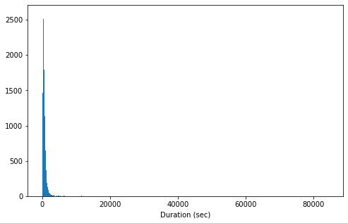

```python
# start with a standard-scaled plot
binsize=10
bins = np.arange(0, bike['duration_sec'].max()+binsize, binsize)

plt.figure(figsize=[8, 5])
plt.hist(data = bike, x = 'duration_sec', bins = bins)
plt.xlabel('Duration (sec)')
plt.show()
```

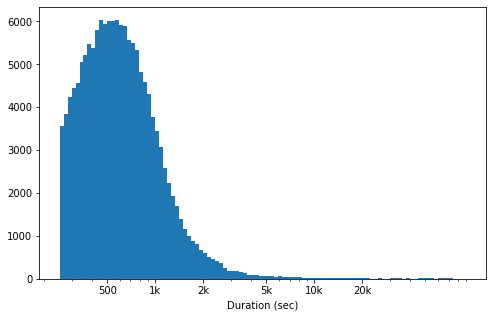

```python
# there's a long tail in the distribution, so let's put it on a log scale instead
log_binsize = 0.025
bins = 10 ** np.arange(2.4, np.log10(bike['duration_sec'].max())+log_binsize, log_binsize)

plt.figure(figsize=[8, 5])
plt.hist(data = bike, x = 'duration_sec', bins = bins)
plt.xscale('log')
plt.xticks([500, 1e3, 2e3, 5e3, 1e4, 2e4], [500, '1k', '2k', '5k', '10k', '20k'])
plt.xlabel('Duration (sec)')
plt.show()
```

The distribution of ride duration is strongly skewed to the right, which means that most rides have duration less than 2k seconds.

#### What is the distribution of members birth year and age?

I would like to explore these two variables together to understand the difference in perception.

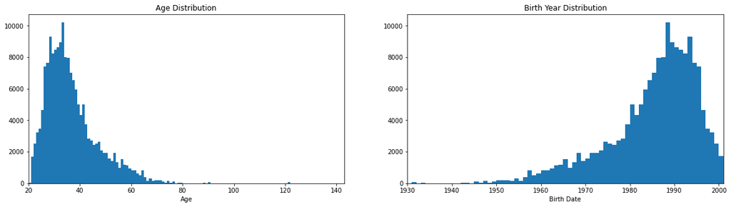

```python
# plotting members birth year time on a standard scale
plt.figure(figsize = [20,5])

plt.subplot(1,2,1)
binsize = 1
bins = np.arange(bike['member_age'].min(), bike['member_age'].max()+binsize, binsize)

plt.hist(data = bike, x = 'member_age', bins = bins)
plt.xlim([bike['member_age'].min(), bike['member_age'].max()])
plt.xlabel('Age')
plt.title('Age Distribution')

plt.subplot(1,2,2)
binsize = 1
bins = np.arange(bike['member_birth_year'].min(), bike['member_birth_year'].max()+binsize, binsize)

plt.hist(data = bike, x = 'member_birth_year', bins = bins)
plt.xlim([1930,2001])
plt.xlabel('Birth Date')
plt.title('Birth Year Distribution')
plt.show()
```

```python
bike['member_birth_year'].describe()
```

```
count    174952.000000
mean       1984.803135
std          10.118731
min        1878.000000
25%        1980.000000
50%        1987.000000
75%        1992.000000
max        2001.000000
Name: member_birth_year, dtype: float64
```

```python
bike['member_age'].describe()
```

```
count    174952.000000
mean         36.196865
std          10.118731
min          20.000000
25%          29.000000
50%          34.000000
75%          41.000000
max         143.000000
Name: member_age, dtype: float64
```

Personally for me, it is easier to think in terms of user age. This is again right-skewed distribution, telling that the mean age of service users is about 36 years.

#### How Many Customers and How Many Subscribers Use the Service?

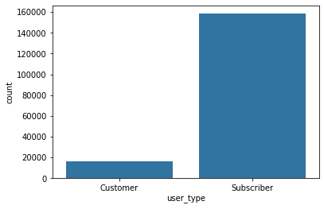

```python
#customer vs subscriber
base_color = sb.color_palette()[0]
sb.countplot(data=bike, x='user_type', color=base_color);
```

The same data on pie chart.

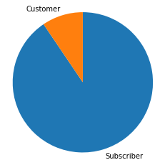

```python
sorted_counts = bike['user_type'].value_counts()

plt.pie(sorted_counts, labels = ['Subscriber','Customer'], startangle = 90, counterclock = False);

plt.axis('square');
```

The chart shows that there are significantly more Subscribers than non-Subscribers.

### Datetime exploration

```python
# Make new columns for analysis (month, day(start day) and hour)

bike['month'] = bike['start_time'].dt.month_name()
bike['day'] = bike['start_time'].dt.day_name()
bike['hour'] = bike['start_time'].dt.hour

bike.head()
```

|  | duration_sec | start_time | end_time | start_station_id | start_station_name | start_station_latitude | start_station_longitude | end_station_id | end_station_name | end_station_latitude | ... | bike_id | user_type | member_birth_year | member_gender | bike_share_for_all_trip | member_age | duration_hours | month | day | hour |
| --- | --- | --- | --- | --- | --- | --- | --- | --- | --- | --- | --- | --- | --- | --- | --- | --- | --- | --- | --- | --- | --- |
| 0 | 52185.0 | 2019-02-28 17:32:10.145 | 2019-03-01 08:01:55.975 | 21 | Montgomery St BART Station (Market St at 2nd St) | 37.789625 | -122.400811 | 13 | Commercial St at Montgomery St | 37.794231 | ... | 4902 | Customer | 1984 | Male | No | 37 | 14.495833 | February | Thursday | 17 |
| 2 | 61854.0 | 2019-02-28 12:13:13.218 | 2019-03-01 05:24:08.146 | 86 | Market St at Dolores St | 37.769305 | -122.426826 | 3 | Powell St BART Station (Market St at 4th St) | 37.786375 | ... | 5905 | Customer | 1972 | Male | No | 49 | 17.181667 | February | Thursday | 12 |
| 3 | 36490.0 | 2019-02-28 17:54:26.010 | 2019-03-01 04:02:36.842 | 375 | Grove St at Masonic Ave | 37.774836 | -122.446546 | 70 | Central Ave at Fell St | 37.773311 | ... | 6638 | Subscriber | 1989 | Other | No | 32 | 10.136111 | February | Thursday | 17 |
| 4 | 1585.0 | 2019-02-28 23:54:18.549 | 2019-03-01 00:20:44.074 | 7 | Frank H Ogawa Plaza | 37.804562 | -122.271738 | 222 | 10th Ave at E 15th St | 37.792714 | ... | 4898 | Subscriber | 1974 | Male | Yes | 47 | 0.440278 | February | Thursday | 23 |
| 5 | 1793.0 | 2019-02-28 23:49:58.632 | 2019-03-01 00:19:51.760 | 93 | 4th St at Mission Bay Blvd S | 37.770407 | -122.391198 | 323 | Broadway at Kearny | 37.798014 | ... | 5200 | Subscriber | 1959 | Male | No | 62 | 0.498056 | February | Thursday | 23 |

5 rows × 21 columns

```python
bike.month.value_counts()
```

```
February    174952
Name: month, dtype: int64
```

There are entries from one month only in the dataset.

#### What is the Distribution of Bike Usage per Day of the Week?

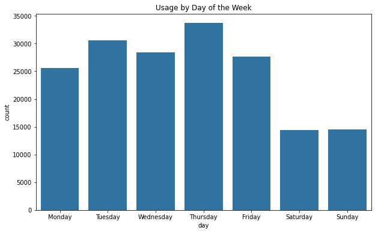

```python
# Countplot bike usage based on weekday

day_name = ["Monday","Tuesday","Wednesday","Thursday","Friday","Saturday","Sunday"]

base_color = sb.color_palette()[0]
plt.figure(figsize=(10,6))
plt.title('Usage by Day of the Week')
sb.countplot(data=bike, x='day', order=day_name, color=base_color);
```

The service is more popular on weekdays rather than on weekend.

#### How Frequently are the Bikes used Depending on the Time of the Day?

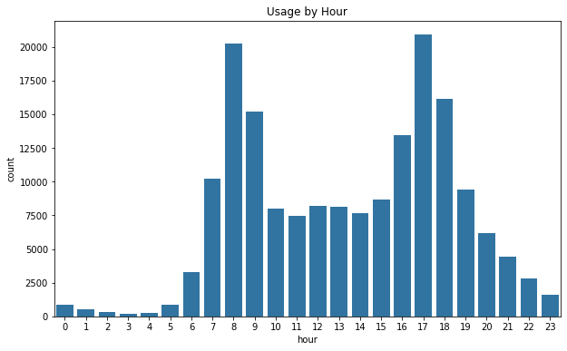

```python
hours = np.arange(0,24)

base_color = sb.color_palette()[0]
plt.figure(figsize=(10,6))
plt.title('Usage by Hour')

sb.countplot(data=bike, x='hour', order=hours, color=base_color);
```

As we can see bikes are the most popular during the rush hours: 8 and 9 am in the morning and 4-6 pm in the evening. They are moderately popular during the day and not popular at all at night.

### Popular stations

#### What are the Most Popular Start Stations?

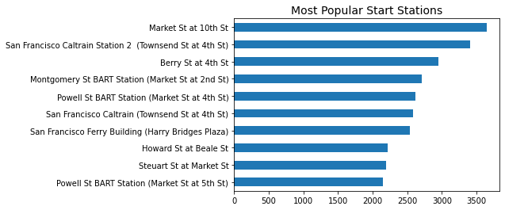

```python
plt.title('Most Popular Start Stations', fontsize=14)
bike.start_station_name.value_counts(ascending=True).tail(10).plot.barh();
```

#### What are the Most Popular End Stations?

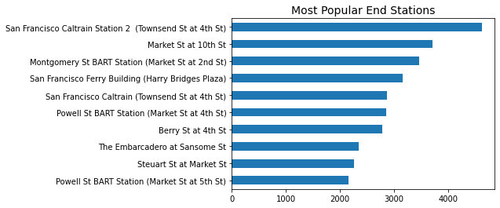

```python
plt.title('Most Popular End Stations', fontsize=14)
bike.end_station_name.value_counts(ascending=True).tail(10).plot.barh();
```

## Bivariate Exploration

### Riding duration based on user age

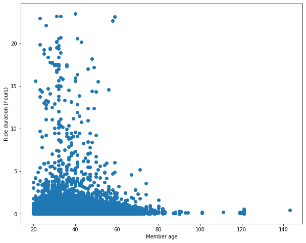

```python
plt.figure(figsize=(10,8))
plt.scatter(data = bike, x = 'member_age', y = 'duration_hours');
plt.xlabel('Member age')
plt.ylabel('Ride duration (hours)');
```

Shorter rides among younger people seem to be the most popular ones.

### Riding duration based on user type

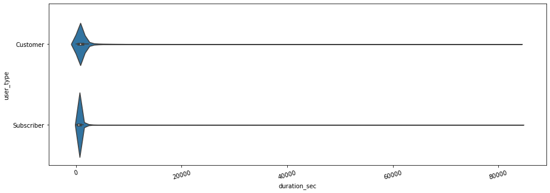

```python
plt.figure(figsize=(15,5))
sb.violinplot(data=bike, y='user_type', x='duration_sec', color=base_color);
plt.xticks(rotation=15);
```

### Bike Usage per Day

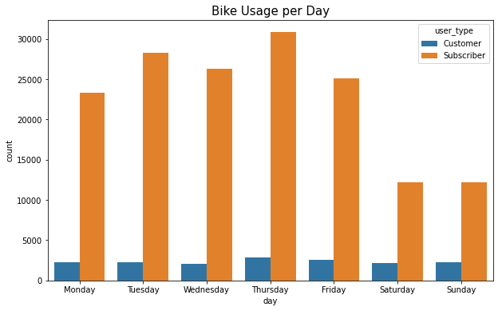

```python
plt.figure(figsize=(10,6))
plt.title('Bike Usage per Day', fontsize=15)
chart = sb.countplot(data=bike, x='day', order=day_name, hue='user_type')
```

While customers are using the bikes more or less equally regardless of the weekday, there is significant reduction of bike usege during the weekends among subscribers.

### Hourly Usage per Day

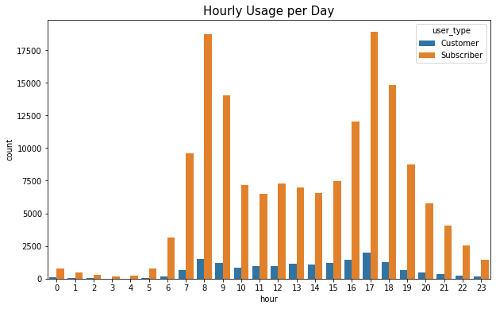

```python
plt.figure(figsize=(10,6))
plt.title('Hourly Usage per Day', fontsize=15)
chart = sb.countplot(data=bike, x='hour', hue='user_type')
```

It seems that both customers and subscribers use bikes more during the rush hours, though the spike is much more significant among subscribers.

### Plotting a Heat Map between Gender and User type

```python
# get the data into desirable format
ct_counts = bike.groupby(['member_gender', 'user_type']).size()
ct_counts = ct_counts.reset_index(name = 'count')
#rearrange data to have vehicle class on rows
ct_counts = ct_counts.pivot(index = 'member_gender', columns = 'user_type', values = 'count')
```

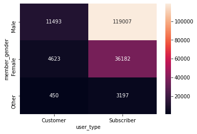

```python
sb.heatmap(ct_counts, annot = True, fmt = 'd');
```

It seems that service users are mostly men, regardless of subscription type.

## Multivariate Exploration

#### Comparing Ride Duration Depending on the Ride Hour and Gender

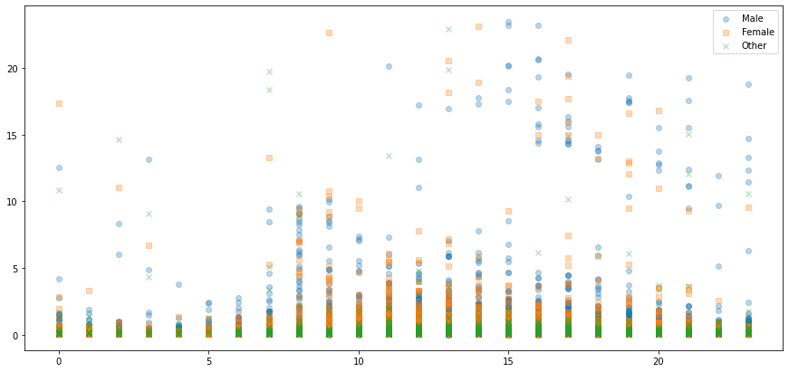

```python
plt.figure(figsize = (15,7))
cat_markers = [['Male', 'o'],
               ['Female', 's'],
               ['Other', 'x']]

for cat, marker in cat_markers:
    df_cat = bike[bike['member_gender'] == cat]
    plt.scatter(data = df_cat, x = 'hour', y = 'duration_hours', marker = marker, alpha = 0.3);
plt.legend(['Male','Female','Other']);
```

#### Comparing Ride Duration Depending on the Ride Hour and User Type

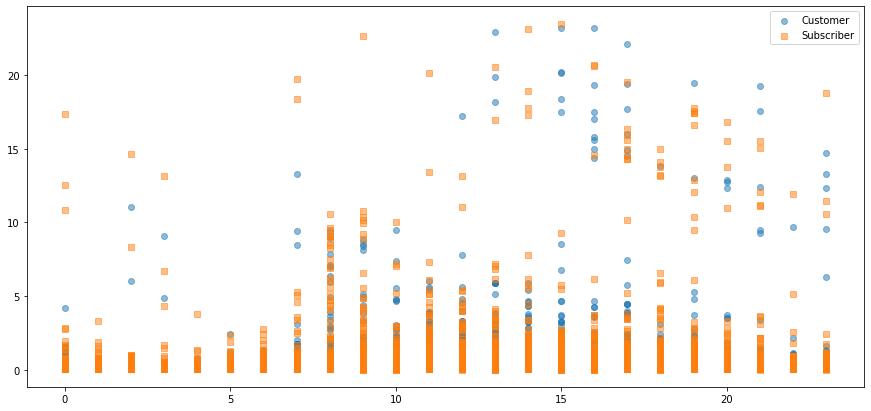

```python
plt.figure(figsize = (15,7))

cat_markers = [['Customer', 'o'],
               ['Subscriber', 's']]

for cat, marker in cat_markers:
    df_cat = bike[bike['user_type'] == cat]
    plt.scatter(data = df_cat, x = 'hour', y = 'duration_hours', marker = marker, alpha=0.5)
plt.legend(['Customer', 'Subscriber']);
```

From this two plots it is just obvious that people mostly use bikes during the day rush hours.

### Ride duration for different age and gender

```python
age_bins = [0, 19, 29, 39, 49, 59,
            69, 79, 89, 99]
age_labels = ['10 - 19', '20 - 29', '30 - 39', '40 - 49', '50 - 59',
              '60 - 69', '70 - 79', '80 - 89', '90 - 99']

bike['age_bin'] = pd.cut(bike['member_age'], bins = age_bins, labels = age_labels, right = False)
```

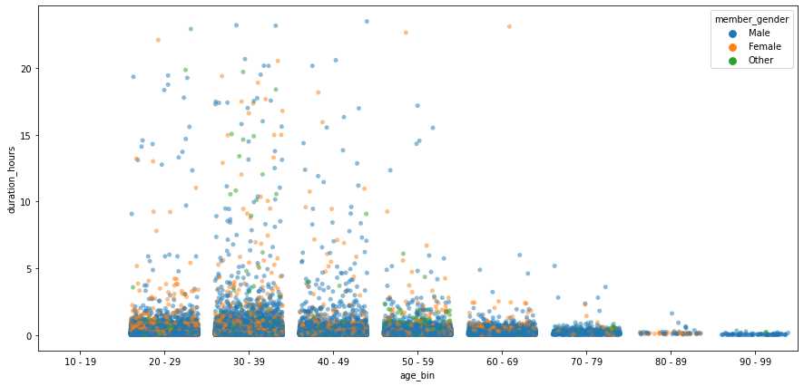

```python
plt.figure(figsize = (15,7))
ax = sb.stripplot(x="age_bin", y="duration_hours", hue="member_gender", data=bike, jitter=0.4, alpha=0.5)
```

People, who have not identified their gender mostly make short-time rides. In general there are more service users among younger people and short rides are more popular than the long rides.

```python
bike.to_csv('bike.csv', index=False)
```

## Conclusions

The most interesting finding for me is a result of map exploration. Visually I have noticed that there are 3 different bike station location areas: San Jose, San Francisco and Oakland .

##### Main Results of Univariate Exploration:

- The distribution of ride duration is strongly skewed to the right, which means that most rides have duration less than 2k seconds, which is approximately half an hour.
- The age distribution is again right-skewed distribution, telling that the mean age of service users is about 36 years.
- There are significantly more Subscribers than non-Subscribers.
- The service is more popular on weekdays rather than on weekend.
- Bikes are the most popular during the rush hours: 8 and 9 am in the morning and 4-6 pm in the evening. They are moderately popular during the day and not popular at all at night.

##### Main Results of Bivariate Exploration:

- Shorter rides (less than 5 hours) among younger people seem to be the most popular ones.
- While customers are using the bikes more or less equally regardless of the weekday, there is significant reduction of bike usege during the weekends among subscribers.
- Both customers and subscribers use bikes more during the rush hours, though this behaviour is much more significant among subscribers.
- The service users are mostly men, regardless of subscription type.